# Cracking The NCAA Team Rankings Code

The Attributes of the Best NCAA Football Playoff Teams Over a Decade

Author

Kyla Rounsoville, Maddie Wilson, Alana Lee

Published

December 8, 2024

# Introduction

College football is a highly valued sport in universities and colleges in the United States. Many college football stars go on to make careers in larger football leagues such as the NFL. Due to the competitive nature of the sport, some individuals have great personal connections with their favorite college football teams. For this reason, when the highly-anticipated AP News rankings of NCAA (division for college football) are released, many football fans have questions about how the top four teams were selected by the NCAA Selection Committee. The committee’s decisions happen in a closed-door meeting between members, and the committee’s decision is final. Some predict that the committee bases their decision on the difficulty of the team’s season, but what does that entail? Defense ability? Number of interceptions? This project aims to crack the code.

In this research project, we will observe data from the top 25 teams in the 2023 season of NCAA college football and analyze how the attributes of the top four teams in 2023 compare to those of the other teams in the past ten years. Conducting an analysis of the rankings for the top four teams based on attribute will allow us to determine which attributes were likely most important in the AP News ranking based on the most recent results (2023).

After determining which categories were most important in the year 2023 – which we did in Figure 1 below – we will apply these factors to the past ten years to examine whether they were also important in the selection of the number one team over an extended period.

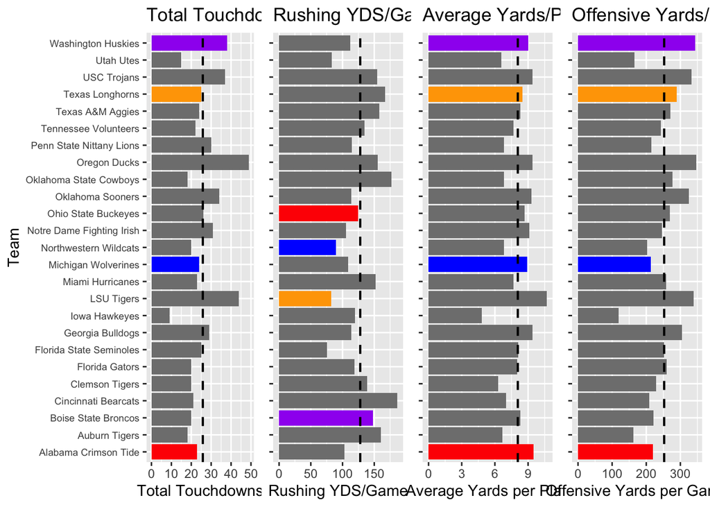

```r
combined_plot
```

Figure 1 - Most Important Factors 2023

The factors we decided were most important in the year 2023 were average offensive yards/pass, number of touchdowns, average defensive yards/game, total offensive yards/game.

In this analysis, we want to answer the question “Which attributes are the most important to the College Football Playoff Selection Committee when selecting the top 4 teams in NCAA College Football?”.

Some may assume that the most important attribute of the top four teams is their ability to score many points in a game, but in the recent 2023 season, the number of points scored does not have a direct correlation with the top four teams.

While many statistical data points are available on each team in the NCAA, it is still difficult to conclude which attributes the committee finds the most important in arriving at their decision. Therefore, our goal with this research project is to conclude which attributes led the committee’s decision to choose the University of Michigan, The University of Washington, The University of Texas, and the University of Alabama as the top four football teams for the 2023 season. After comparing these results to those of previous years, we plan to predict which factors will be most important to the selection committee in choosing the top four teams for this 2024 season.